# Knowledge and use of contraception among Women in Nepal

Findings from the 2018 Demographic and Health Survey

GRAPH Courses Team

Jan 14, 2023

# Dataset description

The dataset we used in this report is a subset of the **Demographic and Health Surveys (DHS)**. The DHS are a serie of standardized surveys conducted periodically in developing countries that collect data on various aspects of population, health, and nutrition. These surveys, which are funded by the United States Agency for International Development (USAID), are a gold-standard source of reliable public health data for many countries and international bodies.

The dataset we used in the report is called *women’s recode dataset*. It contain individual-level data on women aged 15 to 49 in the surveyed households, from Nepal, collected in 2018.

This report focus on family planning in Nepal, in a women perseptive.

The women’s recode dataset contains 12’862 women, aged from 15 to 49 (figure 1.a & 1.b ) ; Half of them have an secondary education or highter (figure 2.a), and 61.1 % are able to read whole sentence (figure 2.b). Two third of the datasets is located in an urban area.

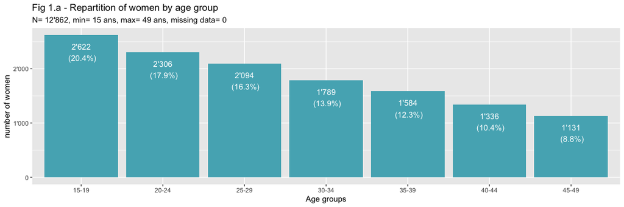

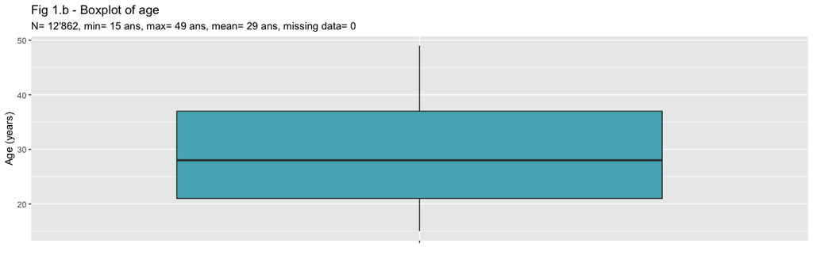

77% are married/living with partner (n= 9904), 2.6% are no longer married (divorced, separated, widowed) (n= 332), and 71.8% (n= 9229) ever had at least 1 child.

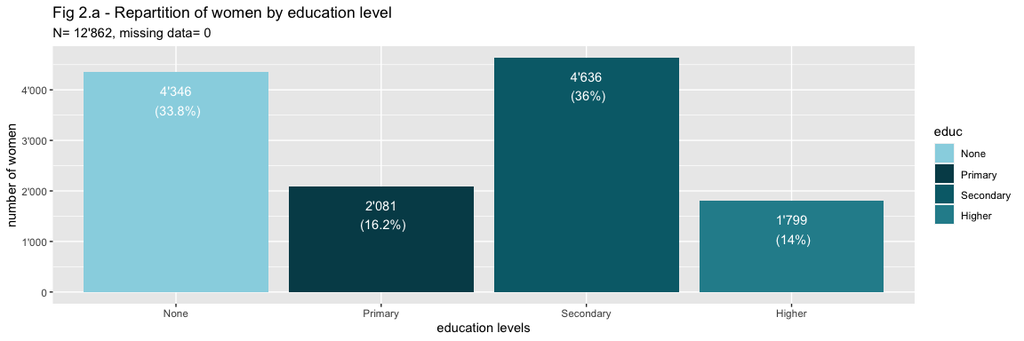

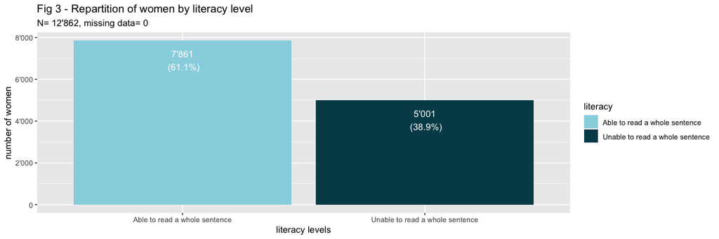

# Knowledge contraception

Allmost all of the 12’862 women has knowledge of at least 1 modern contraceptive method. Only 0.1% of them has no knowledge on modern contraceptive method (fig. 3).

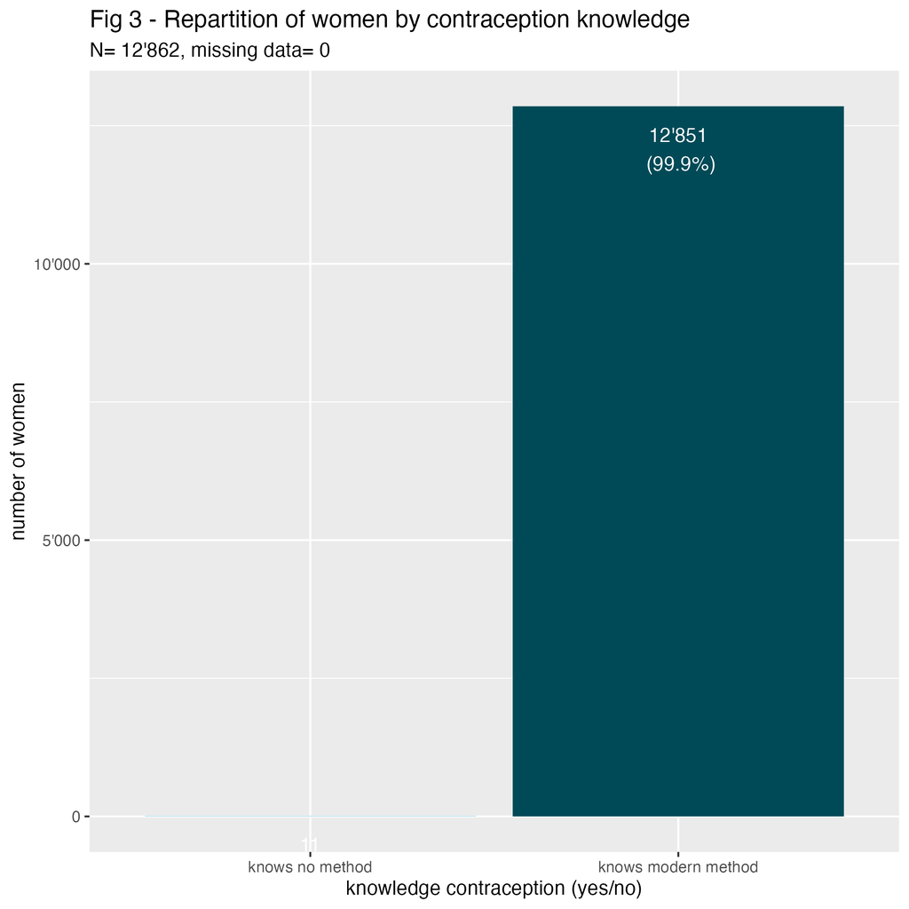

# Child desire

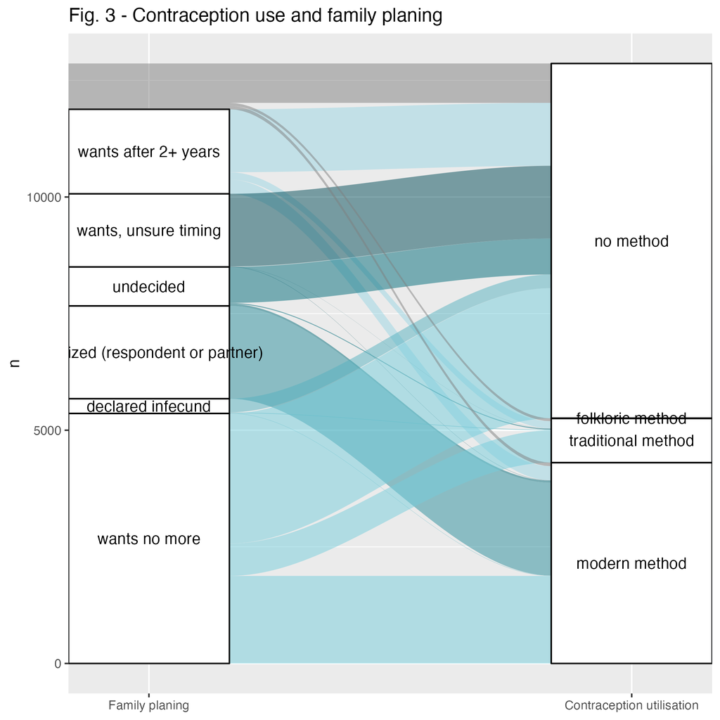